# Statistical Principles and Experimental Design — Seminar 9 Model Selection & Regularization

matthias.kuhn@tu-dresden.de

December 13, 2023 <sub>[e19bf14]</sub>

**(solutions interspersed)**

# Predicting Fat Content of Meat

The fat content is an important characteristic of meat. The reliable but cumbersome method to establish the fat content is via analytic chemistry. A much quicker method to measure the fat content of meat could be based on [near-infrared (NIR) absorbance spectra](https://en.wikipedia.org/wiki/Near-infrared_spectroscopy). To evaluate the aptness of NIR-based method for fat measurement, finely chopped pure meat samples with different fat contents were analysed with respect to their near infrared (NIR) absorbances. Absorbance of a 100 channel spectrum of NIR (wavelength range 850 — 1050 nm) were recorded as -log<sub>10</sub> of the transmittance. As gold standard, the fat content was determined by analytic chemistry and is given in percent. For further details on the data we refer to the publication «Optimal Minimal Neural Interpretation of Spectra» by Borggaard and Thodberg (1992).

The task is to predict the fat content of a meat sample on the basis of its NIR absorbance spectrum. In real applications, the analysis of NIR-spectra is challenging and there is a wide range of analysis strategies.[^1] These strategies typically involve dimension-reduction steps like principle component analysis (PCA) and make use of non-linear models like neural networks to infer chemical information (like fat content) from NIR-spectra. Here in this assignment it will do to apply different linear models with possibly some shrinkage involved.

## Data preparation and descriptive statistics

- Read in the data with the command `readRDS` and store the dataframe under the name `nirData`.
- The data is formatted in «wide format». This means that each measurement has its own column: Check that you have indeed in total data of 215 meat samples with each a fat measurement (column `fat`) and 100 NIR-variables.
- From the full data set, set aside a subset of 25% of all observations as test data set and use the remaining 75% as training data. We explain below why we will *not* use here a separate validation data set.

```r
set.seed(2023) # fix state of R's pseudo-random generator
testIdx <- sample(x=NROW(nirData), size = NROW(nirData)/4)
nirData_test <- dplyr::slice(nirData, testIdx)
nirData_train <- dplyr::slice(nirData, -testIdx)
```

- Within the **training data** only:
  - Visualize and describe the univariate sample distribution of *fat content* (column `fat`): what is the mean and the median fat content in the sample?
  - Each NIR-predictors (aka NIR-*features*) has its own variance. Across the features, what is the range of these variances? What is the mean variance?
  - Look at the correlations among the NIR-features themselves and also the correlation with the response variable `fat`. Try to get an overview, for instance, by considering only — say — every 10<sup>th</sup> feature. What stands out?

**Solution**

We start by reading in the whole data set with the R-function `readRDS`:

```r
nirData <- readRDS("data/NIR_meat.rds")
dim(nirData)
```

```
## [1] 215 101
```

```r
colnames(nirData)
```

```
##   [1] "fat"    "NIR1"   "NIR2"   "NIR3"   "NIR4"   "NIR5"   "NIR6"   "NIR7"   "NIR8"
##  [10] "NIR9"   "NIR10"  "NIR11"  "NIR12"  "NIR13"  "NIR14"  "NIR15"  "NIR16"  "NIR17"
##  [19] "NIR18"  "NIR19"  "NIR20"  "NIR21"  "NIR22"  "NIR23"  "NIR24"  "NIR25"  "NIR26"
##  [28] "NIR27"  "NIR28"  "NIR29"  "NIR30"  "NIR31"  "NIR32"  "NIR33"  "NIR34"  "NIR35"
##  [37] "NIR36"  "NIR37"  "NIR38"  "NIR39"  "NIR40"  "NIR41"  "NIR42"  "NIR43"  "NIR44"
##  [46] "NIR45"  "NIR46"  "NIR47"  "NIR48"  "NIR49"  "NIR50"  "NIR51"  "NIR52"  "NIR53"
##  [55] "NIR54"  "NIR55"  "NIR56"  "NIR57"  "NIR58"  "NIR59"  "NIR60"  "NIR61"  "NIR62"
##  [64] "NIR63"  "NIR64"  "NIR65"  "NIR66"  "NIR67"  "NIR68"  "NIR69"  "NIR70"  "NIR71"
##  [73] "NIR72"  "NIR73"  "NIR74"  "NIR75"  "NIR76"  "NIR77"  "NIR78"  "NIR79"  "NIR80"
##  [82] "NIR81"  "NIR82"  "NIR83"  "NIR84"  "NIR85"  "NIR86"  "NIR87"  "NIR88"  "NIR89"
##  [91] "NIR90"  "NIR91"  "NIR92"  "NIR93"  "NIR94"  "NIR95"  "NIR96"  "NIR97"  "NIR98"
## [100] "NIR99"  "NIR100"
```

We set the seed to get reproducible results and then split the data into training and test data:

```r
set.seed(2023)
```

```r
testIdx <- sample(x=NROW(nirData), size = NROW(nirData)/4)
nirData_test <- dplyr::slice(nirData, testIdx)
nirData_train <- dplyr::slice(nirData, -testIdx)
# check we correctly partitioned the available data
stopifnot(NROW(nirData_train) + NROW(nirData_test) == NROW(nirData))
# outcome variable fat
summary(nirData_train$fat)
```

```
##    Min. 1st Qu.  Median    Mean 3rd Qu.    Max.
##     0.9     7.2    12.6    17.5    27.5    48.2
```

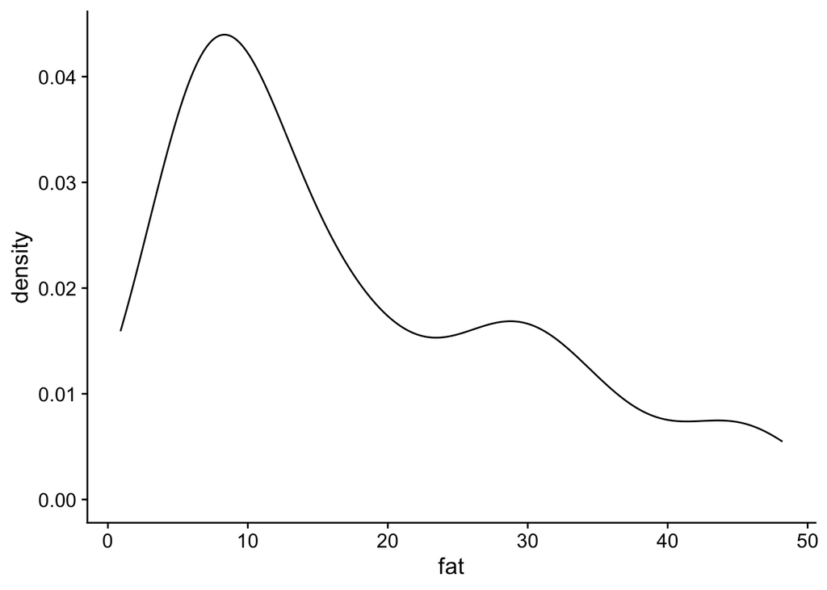

```r
library("ggplot2")
ggplot(data = nirData_train, mapping = aes(x = fat)) +
  geom_density()
```

The outcome variable `fat` is given in percentage, ranging from 0.9 - 48.2. The distribution of fat is right-skewed and we see two peaks around 10% and at 30%.

We look at the variance of the NIR-feature variables using `dplyr`-functions. The data is in wide format but `dplyr` generally works best with data in long format. However, we can use `dplyr::across` to request the empirical variance (function `stats::var`) for each of the NIR-features. To extract the values of variances we transform the variance-output in long format (via `tidyr::pivot_longer`).

```r
nirVar_train <- nirData_train |>
  dplyr::summarise(across(starts_with("NIR"), .fns=var)) |>
  # long format
  tidyr::pivot_longer(cols = everything(),
                      names_to = "feature", values_to = "var")

# get numerical summary of variances
nirVar_train |>
  dplyr::pull(var) |> # extract column var as vector
  summary()
```

```
##    Min. 1st Qu.  Median    Mean 3rd Qu.    Max.
##   0.154   0.214   0.266   0.243   0.272   0.276
```

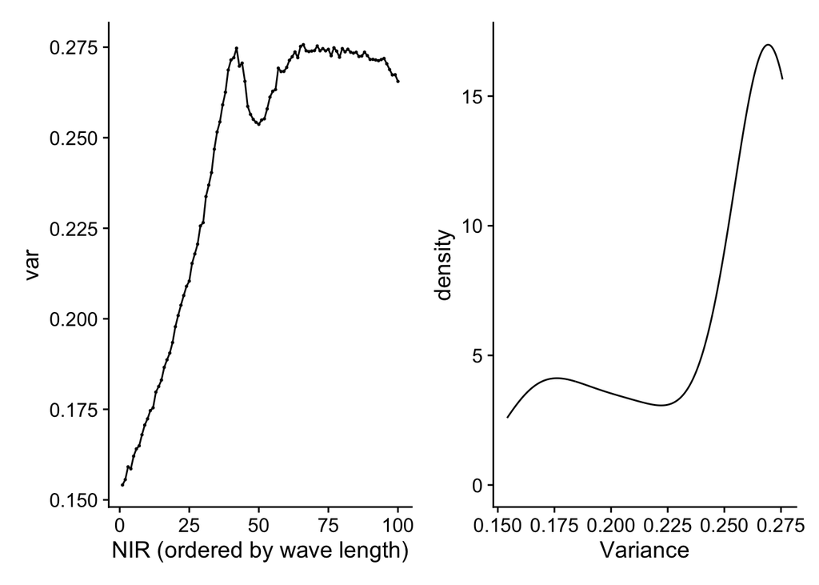

```r
library("readr") # to extract number from character string

# variances as ordered by wave lengths
nirVar_train |>
  dplyr::mutate(featureNbr = readr::parse_number(feature)) |>
  ggplot(mapping = aes(x = featureNbr, y = var)) +
  geom_line() + geom_point(size = .3) +
  labs(x = "NIR (ordered by wave length)") |

# overall distribution (density estimate)
ggplot(nirVar_train,
       mapping = aes(x = var)) +
  geom_density() +
  labs(x = "Variance")
```

All in all, the values for NIR-features lie in the range of 2.043—5.49. The variances of the features range from 0.1541 up to 0.27569. On average, we see a variance of 0.2431. The features on absorbance of small wavelengths (features `NIR1` to `NIR15`) have the lowest variance (< 0.2).

We look at the correlation of fat content and the NIR-features. We show only an excerpt of the full correlation matrix because it is too big to comprehend in all.

```r
# correlation matrix (pairwise Pearson correlations between fat and all NIR-features)
nirFeatureCor_train <- cor(nirData_train)
# excerpt of correlation matrix
nirFeatureCor_train[c(1, 2, 16, 31, 51, 81, 101), seq(to = 101, by = 8)] |>
  signif(digits = 3)
```

```
##          fat  NIR8 NIR16 NIR24 NIR32 NIR40 NIR48 NIR56 NIR64 NIR72 NIR80 NIR88 NIR96
## fat    1.000 0.337 0.349 0.385 0.435 0.490 0.413 0.392 0.395 0.404 0.420 0.446 0.467
## NIR1   0.333 0.999 0.998 0.996 0.990 0.980 0.990 0.978 0.971 0.967 0.966 0.963 0.959
## NIR15  0.347 0.999 0.999 0.998 0.993 0.984 0.992 0.978 0.970 0.967 0.967 0.966 0.964
## NIR30  0.412 0.995 0.996 0.999 0.999 0.995 0.996 0.981 0.974 0.972 0.974 0.975 0.974
## NIR50  0.401 0.989 0.990 0.993 0.994 0.992 0.999 0.995 0.991 0.990 0.989 0.987 0.983
## NIR80  0.420 0.965 0.967 0.972 0.975 0.978 0.987 0.994 0.996 0.998 1.000 0.998 0.993
## NIR100 0.464 0.960 0.963 0.970 0.976 0.980 0.981 0.978 0.979 0.985 0.991 0.997 0.999
```

The fat content is positively correlated with all NIR-features, ranging from 0.333 - 0.494. The highest correlation with fat is reached by NIR41.

The following plot visualizes the relationship of the many predictors and the fat-outcome in the training data. It is a «parallel coordinate plot»[^2] that visualizes the distribution of the NIR-features:

The features of each meat sample are represented by a separate line which shows the absorbance (y-axis) for each wave length in the spectrum (on the x-axis). From the plot we can see that the range of the individual NIR-features in the training data is roughly 2 for the short wave-lengths and the range increases to circa 3 for the longer wave-lengths. The actual outcome variable `fat` for each meat sample is colour-coded: the higher the fat content of a meat sample the darker its feature line is coloured.

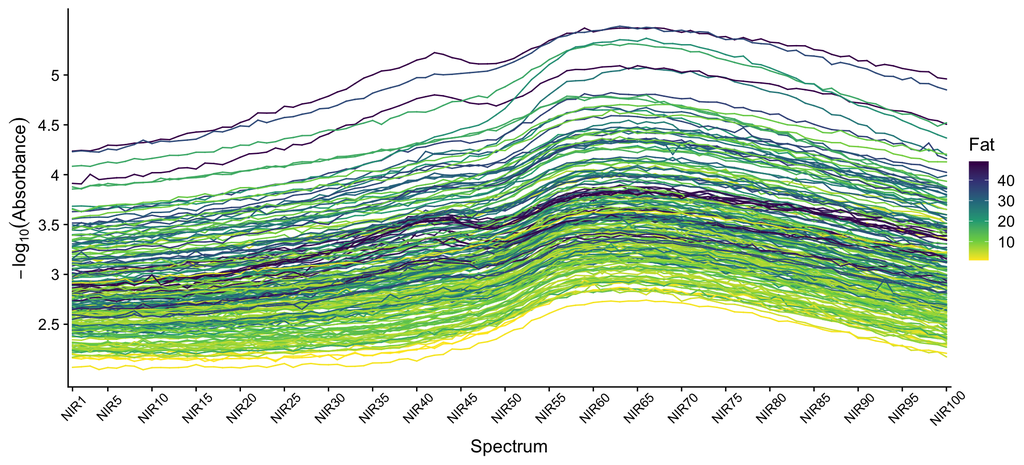

## Linear Model

- Fit an additive model with intercept and all available NIR-predictors on the training data and store the model fit as `nir_lm`. We will use this model as a reference in our benchmark of different models. You do not need to name all features that take part in the regression as predictors. The formula `fat ~ .` specifies variable `fat` as response and the `.` on the right hand side is a shortcut referring to all remaining variables in the dataframe that you specify via `data=`.
- Look at the model summary. What are the statistically significant predictors (at a 5% significance level)?

**Solution**

We use the standard R-function `lm` to fit the *full additive model*. This means, we include all NIR-features but do not include any interactions between the features. Only the main effects are modelled. To this end, we use the `.` abbreviation of the formula interface:

```r
# linear additive model (all predictors are in)
nir_lm <- lm(fat ~ ., data = nirData_train)
summary(nir_lm)
```

```
##
## Call:
## lm(formula = fat ~ ., data = nirData_train)
##
## Residuals:
##    Min     1Q Median     3Q    Max
## -5.105 -1.234  0.229  1.169  5.191
##
## Coefficients:
##             Estimate Std. Error t value Pr(>|t|)
## (Intercept)   20.042      5.554    3.61  0.00062
## NIR1          10.068     30.343    0.33  0.74117
## NIR2          25.429     24.674    1.03  0.30680
## NIR3         -35.934     27.801   -1.29  0.20104
## NIR4          19.063     31.301    0.61  0.54478
## NIR5         -37.216     30.009   -1.24  0.21967
## NIR6         -29.410     26.902   -1.09  0.27859
## NIR7          24.326     30.636    0.79  0.43026
## NIR8          10.633     24.308    0.44  0.66336
## NIR9          54.414     27.679    1.97  0.05387
## NIR10         14.181     35.166    0.40  0.68817
## NIR11        -41.017     33.408   -1.23  0.22426
## NIR12         20.147     33.103    0.61  0.54504
## NIR13        -33.365     28.590   -1.17  0.24774
## NIR14        -52.154     28.841   -1.81  0.07549
## NIR15         34.991     25.671    1.36  0.17786
## NIR16          5.429     25.402    0.21  0.83148
## NIR17         -1.092     33.273   -0.03  0.97393
## NIR18         36.736     25.410    1.45  0.15338
## NIR19         21.670     26.917    0.81  0.42391
## NIR20          9.662     34.200    0.28  0.77850
## NIR21        -41.853     31.053   -1.35  0.18271
## NIR22          8.992     29.480    0.31  0.76140
## NIR23         -4.193     31.401   -0.13  0.89421
## NIR24          3.728     30.079    0.12  0.90177
## NIR25         -8.996     26.579   -0.34  0.73617
## NIR26        -43.005     33.345   -1.29  0.20202
## NIR27         -5.617     24.787   -0.23  0.82148
## NIR28         -1.967     29.930   -0.07  0.94782
## NIR29        -58.233     33.642   -1.73  0.08851
## NIR30        -50.486     28.117   -1.80  0.07752
## NIR31         53.466     26.647    2.01  0.04925
## NIR32         31.957     31.741    1.01  0.31800
## NIR33        -31.271     29.283   -1.07  0.28978
## NIR34        -10.667     30.588   -0.35  0.72849
## NIR35         18.197     36.843    0.49  0.62315
## NIR36        -36.629     28.600   -1.28  0.20513
##  [ reached getOption("max.print") -- omitted 64 rows ]
##
## Residual standard error: 3.07 on 61 degrees of freedom
## Multiple R-squared:  0.977,  Adjusted R-squared:  0.939
## F-statistic: 25.9 on 100 and 61 DF,  p-value: <2e-16
```

It is a long model summary because we have 100 NIR-based predictors, plus intercept. Generally, the estimated coefficients of the NIR-predictor reach from -87 to 62. This means, when an individual NIR-feature is changed by one unit and all other NIR-features are held constant the model predicts a change in fat that lies in this range! This is remarkable as the output variable `fat` is measured on a percentage scale and within the training data, the observed fat ranges only between 0% and 50%. So, the predicted effects of the individual NIR-wavelengths must cancel out each other. We observe that the sign of the parameter estimates frequently changes for adjacent NIR-wavelengths. Generally, positively correlated predictors (e.g., predictors of neighbouring NIR-wavelengths) have negatively correlated predictor coefficients in a linear regression model. This is because the predictors «compete» for explaining change in the outcome variable. The negative correlation is reflected in the variance-covariance matrix of the estimated predictor coefficients, in particular the elements one off the main diagonal are predominantly negative in our full additive model fit:

```r
cor(dplyr::select(nirData, !fat))[1:5, 1:10]
```

```
##         NIR1    NIR2    NIR3    NIR4    NIR5    NIR6    NIR7    NIR8    NIR9   NIR10
## NIR1 1.00000 0.99902 0.99896 0.99909 0.99891 0.99889 0.99879 0.99882 0.99879 0.99864
## NIR2 0.99902 1.00000 0.99896 0.99910 0.99898 0.99888 0.99894 0.99889 0.99891 0.99890
## NIR3 0.99896 0.99896 1.00000 0.99919 0.99888 0.99890 0.99886 0.99881 0.99882 0.99880
## NIR4 0.99909 0.99910 0.99919 1.00000 0.99914 0.99914 0.99908 0.99899 0.99919 0.99905
## NIR5 0.99891 0.99898 0.99888 0.99914 1.00000 0.99909 0.99909 0.99903 0.99905 0.99904
```

```r
# variance-covariance matrix for the parameter estimates: excerpt
vcov(nir_lm)[2:5,2:9]
```

```
##          NIR1    NIR2     NIR3     NIR4     NIR5     NIR6      NIR7      NIR8
## NIR1  920.723 -88.630  -82.981 -240.280  -47.156 -135.921 -107.8191 -183.5002
## NIR2  -88.630 608.805  -77.849   86.294 -199.526   44.882  -27.2329  -74.2881
## NIR3  -82.981 -77.849  772.868 -180.197  -47.397  -84.451 -208.9718  -30.7436
## NIR4 -240.280  86.294 -180.197  979.766 -204.333   35.895   -6.7233   -1.4572
```

```r
# expressed as correlation matrix
cov2cor(vcov(nir_lm))[2:5,2:9]
```

```
##          NIR1     NIR2     NIR3     NIR4      NIR5      NIR6       NIR7       NIR8
## NIR1  1.00000 -0.11838 -0.09837 -0.25298 -0.051787 -0.166507 -0.1159828 -0.2487832
## NIR2 -0.11838  1.00000 -0.11349  0.11173 -0.269467  0.067616 -0.0360262 -0.1238595
## NIR3 -0.09837 -0.11349  1.00000 -0.20708 -0.056813 -0.112918 -0.2453565 -0.0454937
## NIR4 -0.25298  0.11173 -0.20708  1.00000 -0.217532  0.042627 -0.0070111 -0.0019152
```

The standard errors (square root of the diagonal entries of `vcov` and also shown in the summary output of the model) are also very high. This reflects the uncertainty in the parameter estimates. Both facts let us doubt the usefulness and robustness of this full linear model fit.

In this full linear model, only 4 predictors (NIR48, NIR40, NIR55, NIR31) are significant at the 5%-significance level.

## Variable Selection

All absorbance predictors are potentially relevant predictors for fat-level and hence the full linear model seems like the best linear additive model. Nevertheless, we try out two variable selection methods to build two simpler regression models.

### Using AIC

The R-function `step` uses — starting from the provided model fit — the **AIC-criterion** to decide if dropping or adding a variable improves the model. The AIC-criterion balances model fit on the training data with model complexity. Lower values of AIC indicate better fits. For a fitted model with $p$ parameters, AIC is defined as
$$\operatorname{AIC} = -2 \times \text{max. log-likelihood} + 2\times p$$
The negative log-likelihood part quantifies the model fit while $+ 2\times p$ is a penalty for model complexity. Many statisticians consider the AIC to be a better criterion to decide which predictors to drop/add than the F-statistic that you have seen in the lecture.

With argument `direction="both"` in the `step`-function we specify that at each step of the variable selection the variables that were dropped in previous steps are re-considered for inclusion in the model again (why could this be useful?). At each step, intermediate model fits are printed. As this is too verbose in our case we switch that off with the argument `trace = 0`.

Here, we will not consider all model candidates that occur in intermediate steps but retain only the final model of the stepwise selection procedure on the training data. This is why we do not need the validation data set.

- Store the final output model of AIC-based variable selection on the training data. Later, we evaluate this model fit on the reserved test data.
- How many predictors have been retained in the final model after AIC-based stepwise variable selection?
- Why can it happen that a feature variable that was dropped in a previous step is added again in a later step?

**Solution**

We do variable selection with the R-command `step`. By default, it uses the AIC-criterion for variable selection. In each step, that variable is dropped (or re-added) that yields the biggest reduction in AIC.

```r
# trace=0 to suppress lengthy output of intermediate steps
fm_nir_step_AIC <- step(nir_lm, direction = "both", trace = 0)
summary(fm_nir_step_AIC)
```

```
##
## Call:
## lm(formula = fat ~ NIR2 + NIR3 + NIR4 + NIR5 + NIR7 + NIR9 +
##     NIR11 + NIR13 + NIR14 + NIR15 + NIR18 + NIR19 + NIR20 + NIR21 +
##     NIR26 + NIR29 + NIR30 + NIR31 + NIR32 + NIR33 + NIR36 + NIR38 +
##     NIR40 + NIR42 + NIR43 + NIR44 + NIR45 + NIR47 + NIR48 + NIR50 +
##     NIR51 + NIR53 + NIR54 + NIR55 + NIR57 + NIR59 + NIR63 + NIR66 +
##     NIR67 + NIR69 + NIR70 + NIR72 + NIR74 + NIR75 + NIR78 + NIR79 +
##     NIR80 + NIR84 + NIR89 + NIR92 + NIR94 + NIR97 + NIR98, data = nirData_train)
##
## Residuals:
##    Min     1Q Median     3Q    Max
## -6.757 -1.319  0.029  1.301  5.116
##
## Coefficients:
##             Estimate Std. Error t value Pr(>|t|)
## (Intercept)    21.47       3.23    6.65  1.2e-09
## NIR2           29.07      15.71    1.85  0.06708
## NIR3          -25.27      16.39   -1.54  0.12614
## NIR4           35.22      19.04    1.85  0.06710
## NIR5          -42.61      17.72   -2.40  0.01788
## NIR7           29.40      19.28    1.52  0.13020
## NIR9           45.74      18.62    2.46  0.01563
## NIR11         -27.20      17.53   -1.55  0.12380
## NIR13         -50.51      16.27   -3.10  0.00244
## NIR14         -52.74      17.37   -3.04  0.00300
## NIR15          34.12      15.96    2.14  0.03483
## NIR18          34.73      17.05    2.04  0.04405
## NIR19          20.33      16.36    1.24  0.21689
## NIR20          20.99      17.12    1.23  0.22293
## NIR21         -47.67      17.81   -2.68  0.00861
## NIR26         -43.95      19.14   -2.30  0.02355
## NIR29         -64.00      21.93   -2.92  0.00428
## NIR30         -44.66      17.16   -2.60  0.01056
## NIR31          35.86      17.22    2.08  0.03961
## NIR32          39.44      19.66    2.01  0.04735
## NIR33         -27.81      17.41   -1.60  0.11313
## NIR36         -39.08      18.72   -2.09  0.03918
## NIR38          31.21      18.48    1.69  0.09418
## NIR40          58.36      15.10    3.86  0.00019
## NIR42          35.36      18.67    1.89  0.06093
## NIR43          51.08      18.54    2.76  0.00688
## NIR44          31.75      20.66    1.54  0.12723
## NIR45          61.03      20.51    2.98  0.00360
## NIR47         -43.63      17.38   -2.51  0.01353
## NIR48         -56.15      19.80   -2.84  0.00544
## NIR50         -40.07      17.69   -2.27  0.02548
## NIR51         -31.43      18.32   -1.72  0.08914
## NIR53         -31.79      20.22   -1.57  0.11881
## NIR54          59.74      19.65    3.04  0.00297
## NIR55          66.61      17.78    3.75  0.00029
## NIR57         -42.73      18.53   -2.31  0.02303
## NIR59          43.58      16.83    2.59  0.01091
##  [ reached getOption("max.print") -- omitted 17 rows ]
##
## Residual standard error: 2.48 on 108 degrees of freedom
## Multiple R-squared:  0.973,  Adjusted R-squared:  0.96
## F-statistic: 74.7 on 53 and 108 DF,  p-value: <2e-16
```

```r
# number of retained predictors, including intercept
length(coef(fm_nir_step_AIC))
```

```
## [1] 54
```

We use `trace=0` to suppress intermediate model output. The final model has retained 53 NIR-features. This is 53% of the original NIR-features. Looking into the summary we see that through the reduction in predictors the model now finds 30 significant predictors (at the significance level of 5%) which is more than before in the full model. In other words, by dropping redundant (this is: highly correlated) predictors we gain statistical resolution. But the estimated coefficients of the retained NIR-predictors are still large in absolute value which raises doubts if this model produces stable predictions.

During the variable selection procedure, feature variables that were dropped in previous steps are also reconsidered to be added again (default argument `direction="both"` of `step`). This is reasonable because it is possible that a predictor variable $X$ seems uninteresting at first but only because it is clouded by other predictors in the model. Once these are taken out eventually, the predictor $X$ might improve the model again. In other words, there is no such thing as a single parameter estimate in a multiple (linear) model: it all depends on which other parameters are in the model as well. During the AIC-based variable selection, a predictor variable reappears in 0 steps.

### Using BIC

The degree how strongly model complexity is penalized in variable selection can be varied. Using the factor $2$ in the penalization term $2\times p$ gives the AIC, but we can also choose to be more stringent. The Bayesian information criterion (BIC) (also known as Schwarz information criterion as it was proposed first by Gideon E. Schwarz in 1978) uses a factor $\ln(n)$ for the penalization term where $n$ is the number of training data. Hence, when there are at least $n=8$ training data, BIC in general leads to sparser models than AIC.

- Use the parameter `k=` of the `step`-function to adjust the penalization factor to get BIC instead of AIC as variable selection criterion. Confirm that the resulting model is sparser than the model selected by AIC.
- How many predictors in the BIC-model are statistically significant at the significance level of 5%?

**Solution**

We use BIC for variable selection with `step` when we set parameter `k=` to $\ln(n) = 5.0876$.

```r
fm_nir_step_BIC <- step(nir_lm, direction = "both", k = log(nobs(nir_lm)), trace = 0)
summary(fm_nir_step_BIC)
```

```
##
## Call:
## lm(formula = fat ~ NIR4 + NIR13 + NIR21 + NIR29 + NIR30 + NIR40 +
##     NIR42 + NIR45 + NIR50 + NIR74 + NIR92, data = nirData_train)
##
## Residuals:
##    Min     1Q Median     3Q    Max
## -9.314 -1.828  0.445  1.908  7.357
##
## Coefficients:
##             Estimate Std. Error t value Pr(>|t|)
## (Intercept)    26.18       2.80    9.36  < 2e-16
## NIR4           61.81      12.84    4.81  3.6e-06
## NIR13         -58.02      15.27   -3.80  0.00021
## NIR21         -50.47      17.10   -2.95  0.00367
## NIR29         -58.16      19.39   -3.00  0.00317
## NIR30         -37.39      17.08   -2.19  0.03010
## NIR40          42.05      14.61    2.88  0.00457
## NIR42          92.47      15.83    5.84  3.1e-08
## NIR45          75.54      18.08    4.18  5.0e-05
## NIR50         -51.83      14.26   -3.63  0.00038
## NIR74         -51.85       9.32   -5.56  1.2e-07
## NIR92          32.98       5.81    5.67  7.0e-08
##
## Residual standard error: 3.02 on 150 degrees of freedom
## Multiple R-squared:  0.945,  Adjusted R-squared:  0.941
## F-statistic:  235 on 11 and 150 DF,  p-value: <2e-16
```

The BIC-selected model contains 12 parameters (including the intercept). During the BIC-based variable selection, a predictor variable reappears in 1 steps. 11 of the 11 retained predictors are statistically significant at the significance level of 5%. Again, we see that dropping even more less-important predictors leads to an further increase in statistical resolution. Interestingly, from the 4 NIR-features that were significant in the initial full linear model only NIR40 are also retained in the BIC-model and are significant in that model as well.

## Shrinkage Methods

Variable selection either keeps a variable or drops it completely from the model, — it is either-or. The R-package `glmnet` allows for different ways to *continuously* shrink parameter coefficient estimates of a linear regression model. The main functions of the package are `glmnet` and `cv.glmnet`.

Within these functions the parameter `alpha=` specifies the type of continuous penalization:

- `alpha=0` corresponds to **ridge regression**.
- `alpha=1` is **Lasso-regression**.
- a value between 0 and 1 corresponds to a **mixture** of ridge and Lasso-regression and this approach to penalization is called **elastic net**.

`glmnet` and `cv.glmnet` will by default fit models for a whole range of values for the penalization parameter λ, ranging from high penalization (with intercept only model as extreme case) down to very mild penalization that approaches the full unpenalized linear model.

In the lecture, we used a separate validation data set to choose an optimal penalization parameter λ. Here, we make use of **cross-validation (CV)** through the function `cv.glmnet`: The training data is divided internally into ten equally-sized folds. Each fold is used once in turn as validation data while the remaining nine folds serve as training data. As a result, we get for each value of λ ten prediction error estimates for $\operatorname{Err}_{\mathcal{T}}$, calculated as mean squared error. The `cv.glmnet`-object contains the mean of these ten cross-validated errors (entry `cvm`) and the estimate of its standard error (entry `cvsd`) for each value of λ. For model selection, you can choose that value for the penalization parameter λ that minimizes the mean cross-validation error (entry `lambda.min`) or — as the authors of the `glmnet` package recommend — choose the largest value of penalization parameter λ such that the cross-validated prediction error is within one standard error of the minimum (entry `lambda.1se`). Doing so we acknowledge that the cross-validated prediction errors are *estimates* and we rather take a simpler model with a stronger penalty that has a comparable error to the best performing model.

`cv.glmnet` does already the recommended centring and scaling of the predictor variables for you (via its default argument `standardize=TRUE`) so that you do not have to do it manually. But unfortunately, `glmnet` does not support the formula interface that we have come to appreciate with `lm` and we have to prepare the data as response vector and predictor matrix:

```r
# glmnet works with vectors and matrices (and, alas, not with the formula interface)
# training data
y_train <- nirData_train |> dplyr::pull(fat)
x_train <- nirData_train |> dplyr::select(!fat) |> as.matrix()
```

- Use the function `cv.glmnet` from the `glmnet`-package to fit penalized regression models. This function chooses a sequence of candidate values for the penalization parameter λ. This default is fine for us here, — you do **not** need to specify your own sequence via parameter `lambda=`. Also, please do not use function `glmnet` with a single value for `lambda=`. The object returned by `cv.glmnet` has all information needed. Concretely, fit three different models in the given order:
  1. Ridge regression
  2. Lasso-regression
  3. Elastic net as mixture of ridge and Lasso-regression, with mixing parameter α = 0.3. (With α = 0.3, we choose a stronger contribution of ridge regression because we have so strongly correlated predictors where ridge regression is designed for.)
- Identify for each of the three models classes the value for the penalization parameter λ so that the cross-validated prediction error is within one standard error of the minimum prediction error. Use `coef` on the respective `cv.glmnet`-object.
- How are the model coefficients affected by the penalization? Compare the estimated coefficients with those from the full linear model.

**Solution**

We use the function `cv.glmnet` three times to fit the three model classes. `cv.glmnet`-objects come with their own plotting routine that highlights the value of λ<sub>min</sub> that minimizes the mean squared error in cross-validation and the value λ<sub>1SE</sub> that yields a cross-validated prediction error is within one standard error of the minimum.

Note that the exact result of `cv.glmnet` also depends on the state of the pseudo-random generator because the cross-validation uses a random allocation of folds. In this assignment, we set the seed initially as shown in the beginning and fit first ridge regression, then lasso and finally elastic net.

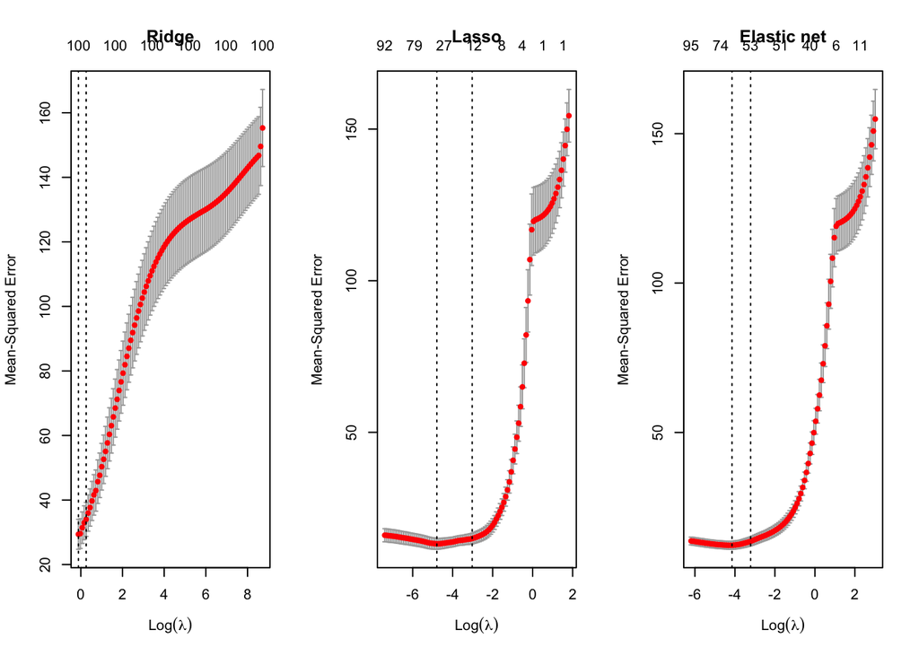

```r
# load glmnet-package (needs to installed once before on your computer)
library("glmnet")

fm_nir_ridge_cv <- cv.glmnet(x = x_train, y = y_train, alpha = 0)
fm_nir_lasso_cv <- cv.glmnet(x = x_train, y = y_train, alpha = 1)
fm_nir_elnet_cv <- cv.glmnet(x = x_train, y = y_train, alpha = .3)

coef_nir_ridge_cv <- coef(fm_nir_ridge_cv, s = "lambda.1se")
coef_nir_lasso_cv <- coef(fm_nir_lasso_cv, s = "lambda.1se")
coef_nir_elnet_cv <- coef(fm_nir_elnet_cv, s = "lambda.1se")

par(mfrow = c(1, 3)) # three base-plots in a row
plot(fm_nir_ridge_cv, main = "Ridge")
plot(fm_nir_lasso_cv, main = "Lasso")
plot(fm_nir_elnet_cv, main = "Elastic net")
```

As λ<sub>1SE</sub>, we get

- 1.29091 for ridge regression,
- 0.0486 for Lasso regression *and*
- 0.04013 for elastic net (with fixed mixing parameter α = 0.3).

The parameter estimates for all the NIR-features move closer to zero, although the selected penalization parameters λ<sub>1SE</sub> are rather small for all three models, which corresponds to low penalization.

In ridge regression with λ<sub>1SE</sub>=1.29 we see a drastic effect on the estimates of the model parameters: the coefficient estimates for the NIR-predictors range from -5.5 up to 8 which is a way shorter range than the range of the coefficient estimates of the full linear model -86.6 up to 61.7. In ridge regression, none of the estimated predictors are really zero, though.

With Lasso, the coefficients range from -35.8 up to 45.9. This is a wider range for the coefficients than with ridge regression. But the L<sub>1</sub>-penalization forces 88 of the NIR-feature coefficients to be zero. A coefficient of zero means that the predictor is effectively dropped from the model. This highlights the built-in variable selection property of Lasso-regression.

With elastic net (α = 0.3), 47 of the predictors are dropped. The coefficients range from -15.6 up to 26.2, a shorter range than when using pure L<sub>1</sub>-penalization.

## Model Assessment

We have fitted different models on the NIR-training data. Now, we want to use the reserved test data to assess these models.

Rank the six models based on the mean squared error they achieve on the test data. Use `predict` to get the model prediction for new data. Check the help-pages for the relevant `predict`-functions: see `?predict.lm` and `?predict.cv.glmnet`. For the shrinkage-models from `glmnet`-package you need to prepare the test data as response vector and predictor matrix as `glmnet`-package does not support the formula interface.

```r
y_test <- nirData_test |> dplyr::pull(fat)
x_test <- nirData_test |> dplyr::select(!fat) |> as.matrix()

modelPerf <- c(
  # lm-models
  lm=mean((y_test - predict(nir_lm, newdata = nirData_test))^2),
  step_AIC=mean((y_test - predict(fm_nir_step_AIC, newdata = nirData_test))^2),
  step_BIC=mean((y_test - predict(fm_nir_step_BIC, newdata = nirData_test))^2),
  # glmnet-models
  ridge=mean((y_test - predict(fm_nir_ridge_cv, newx = x_test, s = "lambda.1se"))^2),
  lasso=mean((y_test - predict(fm_nir_lasso_cv, newx = x_test, s = "lambda.1se"))^2),
  elnet=mean((y_test - predict(fm_nir_elnet_cv, newx = x_test, s = "lambda.1se"))^2)
)
```

Model Performance as mean squared prediction error (MSE) on test data

| Model Class | Test Error | Rank |
| --- | --- | --- |
| elnet | 11.51 | 1 |
| lasso | 11.63 | 2 |
| step_BIC | 16.31 | 3 |
| step_AIC | 24.98 | 4 |
| ridge | 26.25 | 5 |
| lm | 31.09 | 6 |

We store the mean squared error $\operatorname{Err}_{\mathcal{T}}$ for each of the six models in a vector and we display the results in a table. We rank the models according to the test error. In this example, elastic net shows the smallest prediction error on test data and it is hence the best of the studied models for this data set. Ridge regression and the full additive model perform the worst on the test data even if this method was designed to work with correlated predictors.

But please do not generalize too quickly. The model prediction performance really depends on the problem at hand and you better check the performance of your models for each data modelling task afresh.

# Machine learning infrastructure in R

Model building and selection is a big topic in machine learning. There are at least three packages that in fact provide a whole framework to do model selection and model assessment in R.

1. [modelr](https://modelr.tidyverse.org/) – a lean package to help you create pipelines when modelling, in particular useful for resampling methods. Development of this package has been mostly suspended in favour of the `tidymodels` package.
2. [tidymodels](https://www.tidymodels.org) – a collection of packages for modelling and machine learning using tidyverse principles. Personally, I find the wealth of tidymodels-packages exuberant.
3. [mlr3](https://mlr-org.com/) – «machine learning in R». It is a well-designed package that covers many aspects of machine learning. It uses a different programming style from tidyverse.

In particular the last two packages define a unified programming interface to the different steps needed for statistical model building strategies. The advantage is that the framework covers a vast number of different model classes and fitting routines. Ridge regression and Lasso are just two of the supported regression models, further supported models are random forests, neural networks or support vector machines.

Have a look at the package homepages to get an idea how they work. It is definitely worth it to learn one of these frameworks if you want to do more machine learning in R.

[^1]: A compilation of software packages is listed, for instance, at https://bryanhanson.github.io/FOSS4Spectroscopy/ and, specifically for R, at https://cran.r-project.org/web/views/ChemPhys.html#spectroscopy.
[^2]: We use the the R-package `ggpcp` to produce this plot. For more details how to produce a parallel coordinate plot from scratch see for instance https://ggplot2-book.org/programming.html#functions